# R Notebook

## IFN/TNF double positive

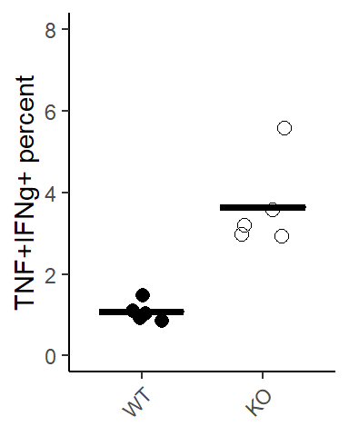

```r
influenza_KC27 %>%
  ggplot(aes(x = Genotype, y = TNFposIFNgpos, shape = Genotype)) +
    stat_summary(geom = "crossbar", fun = "mean", fun.min = "mean", fun.max = "mean", width=0.7, colour = "black") +
    geom_jitter(height = 0, width=0.2, size = 2.5) +
    scale_shape_manual(values = c(16, 1)) +
    theme(legend.position = "none") +
    theme(axis.text.x = element_text(angle = 45, hjust = 1)) +
    coord_cartesian(ylim = c(0,8)) +
    labs(x = NULL, y = "TNF+IFNg+ percent")
```

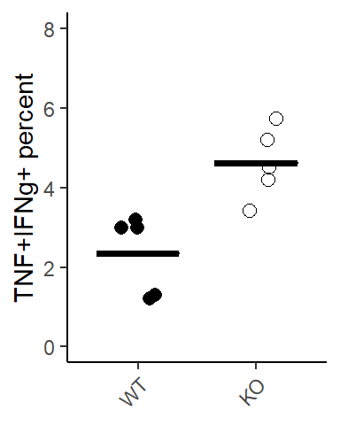

```r
influenza_KC45 %>%
  ggplot(aes(x = Genotype, y = TNFposIFNgpos, shape = Genotype)) +
    stat_summary(geom = "crossbar", fun = "mean", fun.min = "mean", fun.max = "mean", width=0.7, colour = "black") +
    geom_jitter(height = 0, width=0.2, size = 2.5) +
    scale_shape_manual(values = c(16, 1)) +
    theme(legend.position = "none") +
    theme(axis.text.x = element_text(angle = 45, hjust = 1)) +
    coord_cartesian(ylim = c(0,8)) +
    labs(x = NULL, y = "TNF+IFNg+ percent")
```

```r
ggsave("Figure_panels/Fig7K_IFNTNFpercent_KC45flu.pdf", useDingbats = F)
```

Pattern also the same for IFNg+TNF+ double positive

T-tests:

```r
t.test(TNFposIFNgpos ~ Genotype, influenza_KC27)
```

```
##
##  Welch Two Sample t-test
##
## data:  TNFposIFNgpos by Genotype
## t = -5.0632, df = 4.3874, p-value = 0.005587
## alternative hypothesis: true difference in means between group WT and group KO is not equal to 0
## 95 percent confidence interval:
##  -3.922349 -1.205651
## sample estimates:
## mean in group WT mean in group KO
##            1.080            3.644
```

```r
t.test(TNFposIFNgpos ~ Genotype, influenza_KC45)
```

```
##
##  Welch Two Sample t-test
##
## data:  TNFposIFNgpos by Genotype
## t = -3.78, df = 7.9095, p-value = 0.005501
## alternative hypothesis: true difference in means between group WT and group KO is not equal to 0
## 95 percent confidence interval:
##  -3.6575747 -0.8824253
## sample estimates:
## mean in group WT mean in group KO
##             2.34             4.61
```

Significant for both

## Granzyme B percentage

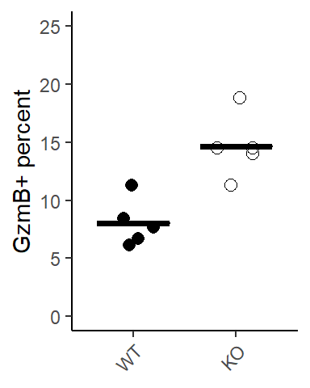

```r
influenza_KC27 %>%
  ggplot(aes(x = Genotype, y = GzmBpos, shape = Genotype)) +
    stat_summary(geom = "crossbar", fun = "mean", fun.min = "mean", fun.max = "mean", width=0.7, colour = "black") +
    geom_jitter(height = 0, width=0.2, size = 2.5) +
    scale_shape_manual(values = c(16, 1)) +
    theme(legend.position = "none") +
    theme(axis.text.x = element_text(angle = 45, hjust = 1)) +
    coord_cartesian(ylim = c(0,25)) +
    labs(x = NULL, y = "GzmB+ percent")
```

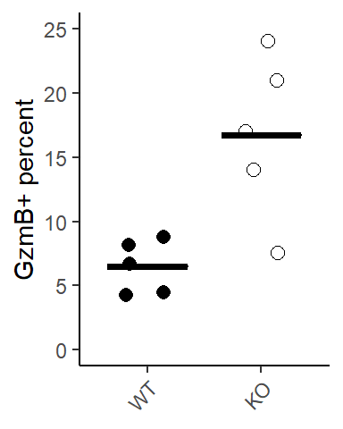

```r
influenza_KC36 %>%
  ggplot(aes(x = Genotype, y = GzmBpos, shape = Genotype)) +
    stat_summary(geom = "crossbar", fun = "mean", fun.min = "mean", fun.max = "mean", width=0.7, colour = "black") +
    geom_jitter(height = 0, width=0.2, size = 2.5) +
    scale_shape_manual(values = c(16, 1)) +
    theme(legend.position = "none") +
    theme(axis.text.x = element_text(angle = 45, hjust = 1)) +
    coord_cartesian(ylim = c(0,25)) +
    labs(x = NULL, y = "GzmB+ percent")
```

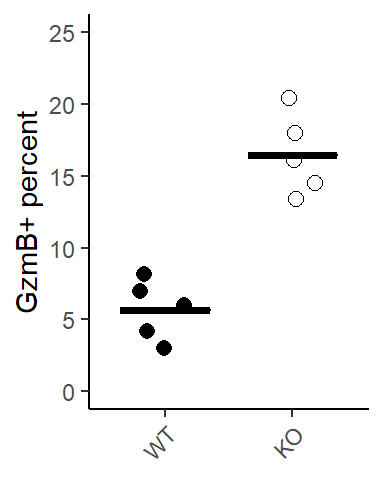

```r
influenza_KC45 %>%
  ggplot(aes(x = Genotype, y = GzmBpos, shape = Genotype)) +
    stat_summary(geom = "crossbar", fun = "mean", fun.min = "mean", fun.max = "mean", width=0.7, colour = "black") +
    geom_jitter(height = 0, width=0.2, size = 2.5) +
    scale_shape_manual(values = c(16, 1)) +
    theme(legend.position = "none") +
    theme(axis.text.x = element_text(angle = 45, hjust = 1)) +
    coord_cartesian(ylim = c(0,25)) +
    labs(x = NULL, y = "GzmB+ percent")
```

```r
ggsave("Figure_panels/Fig7H_GzmBpercent_KC45flu.pdf", useDingbats = F)
```

T-tests:

```r
t.test(GzmBpos ~ Genotype, influenza_KC27)
```

```
##
##  Welch Two Sample t-test
##
## data:  GzmBpos by Genotype
## t = -4.3692, df = 7.4302, p-value = 0.002843
## alternative hypothesis: true difference in means between group WT and group KO is not equal to 0
## 95 percent confidence interval:
##  -10.090515  -3.057485
## sample estimates:
## mean in group WT mean in group KO
##            8.046           14.620
```

```r
t.test(GzmBpos ~ Genotype, influenza_KC36)
```

```
##
##  Welch Two Sample t-test
##
## data:  GzmBpos by Genotype
## t = -3.4077, df = 4.8393, p-value = 0.02009
## alternative hypothesis: true difference in means between group WT and group KO is not equal to 0
## 95 percent confidence interval:
##  -18.010547  -2.433453
## sample estimates:
## mean in group WT mean in group KO
##            6.490           16.712
```

```r
t.test(GzmBpos ~ Genotype, influenza_KC45)
```

```
##
##  Welch Two Sample t-test
##
## data:  GzmBpos by Genotype
## t = -6.9143, df = 7.4186, p-value = 0.0001749
## alternative hypothesis: true difference in means between group WT and group KO is not equal to 0
## 95 percent confidence interval:
##  -14.451676  -7.148324
## sample estimates:
## mean in group WT mean in group KO
##             5.68            16.48
```

Significant for all

## Granzyme B MFI

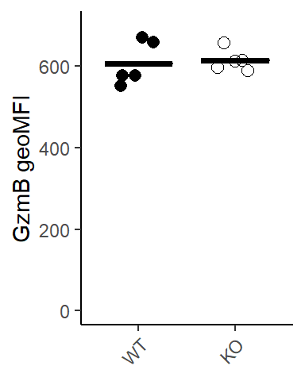

```r
influenza_KC27 %>%
  ggplot(aes(x = Genotype, y = GzmB_geomean, shape = Genotype)) +
    stat_summary(geom = "crossbar", fun = "mean", fun.min = "mean", fun.max = "mean", width=0.7, colour = "black") +
    geom_jitter(height = 0, width=0.2, size = 2.5) +
    scale_shape_manual(values = c(16, 1)) +
    theme(legend.position = "none") +
    theme(axis.text.x = element_text(angle = 45, hjust = 1)) +
    coord_cartesian(ylim = c(0,700)) +
    labs(x = NULL, y = "GzmB geoMFI")
```

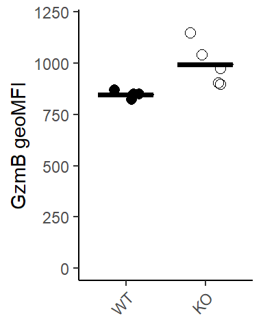

```r
influenza_KC36 %>%
  ggplot(aes(x = Genotype, y = GzmB_geomean, shape = Genotype)) +
    stat_summary(geom = "crossbar", fun = "mean", fun.min = "mean", fun.max = "mean", width=0.7, colour = "black") +
    geom_jitter(height = 0, width=0.2, size = 2.5) +
    scale_shape_manual(values = c(16, 1)) +
    theme(legend.position = "none") +
    theme(axis.text.x = element_text(angle = 45, hjust = 1)) +
    coord_cartesian(ylim = c(0,1200)) +
    labs(x = NULL, y = "GzmB geoMFI")
```

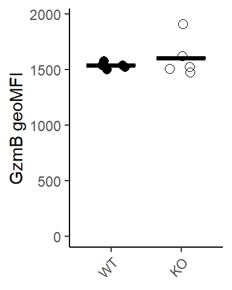

```r
influenza_KC45 %>%
  ggplot(aes(x = Genotype, y = GzmB_geomean, shape = Genotype)) +
    stat_summary(geom = "crossbar", fun = "mean", fun.min = "mean", fun.max = "mean", width=0.7, colour = "black") +
    geom_jitter(height = 0, width=0.2, size = 2.5) +
    scale_shape_manual(values = c(16, 1)) +
    theme(legend.position = "none") +
    theme(axis.text.x = element_text(angle = 45, hjust = 1)) +
    coord_cartesian(ylim = c(0,1950)) +
    labs(x = NULL, y = "GzmB geoMFI")
```

```r
ggsave("Figure_panels/Fig7I_GzmBmfi_KC45flu.pdf", useDingbats = F)
```

In KC36 it does look like there’s an increase, but this is not consistent in the other experiments.

T-tests:

```r
t.test(GzmB_geomean ~ Genotype, influenza_KC27)
```

```
##
##  Welch Two Sample t-test
##
## data:  GzmB_geomean by Genotype
## t = -0.2704, df = 5.8568, p-value = 0.7961
## alternative hypothesis: true difference in means between group WT and group KO is not equal to 0
## 95 percent confidence interval:
##  -72.74302  58.34302
## sample estimates:
## mean in group WT mean in group KO
##            607.4            614.6
```

```r
t.test(GzmB_geomean ~ Genotype, influenza_KC36)
```

```
##
##  Welch Two Sample t-test
##
## data:  GzmB_geomean by Genotype
## t = -3.0543, df = 4.1962, p-value = 0.03556
## alternative hypothesis: true difference in means between group WT and group KO is not equal to 0
## 95 percent confidence interval:
##  -274.03285  -15.56715
## sample estimates:
## mean in group WT mean in group KO
##            846.8            991.6
```

```r
t.test(GzmB_geomean ~ Genotype, influenza_KC45)
```

```
##
##  Welch Two Sample t-test
##
## data:  GzmB_geomean by Genotype
## t = -0.87373, df = 4.2203, p-value = 0.4292
## alternative hypothesis: true difference in means between group WT and group KO is not equal to 0
## 95 percent confidence interval:
##  -288.7563  148.3563
## sample estimates:
## mean in group WT mean in group KO
##           1535.4           1605.6
```

Significant for KC36 but nowhere near for the others - there may be a difference in some cases but it is not consistent. KC45 is appropriate to use as representative since it does not show a difference (although mean is slightly higher and one mouse is higher).